# Titanic: an Introduction to Feature Engineering

Harry Emeric

19 October, 2017

# Introduction

This is my first attempt at Kaggle and writing a full data project. I focuss here on Feature Engineering, my next Kernel will take more of a look at the modelling and diagnostic side. Please reach out with any questions or advice, I’m here to learn and build my network.

## Loading libraries and data

```r
# Loading libraries
library(ggplot2) #charting
library(plyr) #data wrangling
library(dplyr) #data wrangling
library(Hmisc) #data wrangling
library(mice) #imputing variables
library(randomForest) #modelling
library(caret) #modelling
if(!file.exists("./TitanicTrain.csv")) {
        download.file("https://storage.googleapis.com/kaggle-competitions-data/kaggle/3136/train.csv?GoogleAccessId=competitions-data@kaggle-161607.iam.gserviceaccount.com&Expires=1508658187&Signature=WhwpAndrqdR7rqX8bgE9ynM1FPu9ihthWIMf%2Bz8ualnljh1RCDW9dLGVENX%2BdHw7YfY3jzuAV5ao4MFPzwnwkYCapqZYzAFgRqa4A%2BxIZZNjFlzocPjI6JIKxCsOw9WM7t3PahD7oZJHmVNHDan66VCx1WPb7v6t%2FiHR9LzQCFKpQbD3ceiU6bN1mT8ECmCH9gjcrgiDqGADMf0GRK%2BmsHKoTWCnnqNBh8UIi1aYFIcL3xF5SNJGC91P35lu5b8t4wSJLNuNhA05I823a3RbmoF2Rmk4LzIhm9Uv52OVXUcFG36TesdtmaJSLYCNUEYaXt9DeK%2B2vQF55BoT2YI5JQ%3D%3D","./TitanicTrain.csv",method = "curl")}
if(!file.exists("./TitanicTest.csv")) {
        download.file("https://storage.googleapis.com/kaggle-competitions-data/kaggle/3136/test.csv?GoogleAccessId=competitions-data@kaggle-161607.iam.gserviceaccount.com&Expires=1508658217&Signature=dvuLq8iI%2B5KTGzsUnkU%2Fxraxrcq197tIcGtDRAJijJhDImPrTQI0eo6ryXfd9yxcjbFr8QkXN%2FiyKKrZSfm9BVR9R%2BGpqeGZgq%2F8kdTrMc9AuDzg2HsQHTqCXrUGROpHGp7xlWo8qM160m9Rr4jG6hldzWLlmugcvN37q%2BfJYrMf0%2F9XGwDj76S6hUbgAZ6RoBOwUtBzH8CXErufmoOVpPFrZ0Ey9rSZ5jK8UCbGS58TsmkytHMZvjYdXYZGEtbeTZDzZAWap0Vqd6%2FnTgx0n35NyC1uRJ0vUzfAAb2qyvLCxr1WhVVaiLpPKkYWrOMUQyCZP6J0GHZz1GJgq1VYnA%3D%3D","./TitanicTest.csv",method = "curl")}
traindata <- read.csv("./TitanicTrain.csv",stringsAsFactors = FALSE)
testdata <- read.csv("./TitanicTest.csv",stringsAsFactors = FALSE)
c(object.size(traindata),object.size(testdata)) ## data is small so performance shouldn't be an issue
```

```
[1] 179136  86008
```

```r
## I want to combine training and test sets because this makes it easier to perform the same
## operations on both sets
testdata$Survived <- "NA"
merged <- rbind(traindata,testdata)
length(unique(merged$PassengerId)) == length(merged$PassengerId) ## check no duped entries
```

```
[1] TRUE
```

# Pre Clean Exploratory Data Analysis

I find it useful to guess what I think data will look like, as this gives me a benchmark to either support or attack in my initial analysis. Intuitively I would guess that anyone of higher class, either by ticket class itself or cost, would have a better chance of survival, as would women, children, and the elderly. Perhaps families too would be given a better chance of all getting into a lifeboat together as opposed to someone travelling alone?

For detailed impormation about features check here https://www.kaggle.com/c/titanic/data

```r
head(merged) ## for detailed impormation about features check here https://www.kaggle.com/c/titanic/data
```

|  | PassengerId | Survived | Pclass | Name | Sex | Age | SibSp | Parch | Ticket | Fare | Cabin | Embarked |
| --- | --- | --- | --- | --- | --- | --- | --- | --- | --- | --- | --- | --- |
| 1 | 1 | 0 | 3 | Braund, Mr. Owen Harris | male | 22 | 1 | 0 | A/5 21171 | 7.2500 |  | S |
| 2 | 2 | 1 | 1 | Cumings, Mrs. John Bradley (Florence Briggs Thayer) | female | 38 | 1 | 0 | PC 17599 | 71.2833 | C85 | C |
| 3 | 3 | 1 | 3 | Heikkinen, Miss. Laina | female | 26 | 0 | 0 | STON/O2. 3101282 | 7.9250 |  | S |
| 4 | 4 | 1 | 1 | Futrelle, Mrs. Jacques Heath (Lily May Peel) | female | 35 | 1 | 0 | 113803 | 53.1000 | C123 | S |
| 5 | 5 | 0 | 3 | Allen, Mr. William Henry | male | 35 | 0 | 0 | 373450 | 8.0500 |  | S |
| 6 | 6 | 0 | 3 | Moran, Mr. James | male | NA | 0 | 0 | 330877 | 8.4583 |  | Q |

```r
colSums(is.na(merged))
```

```
PassengerId    Survived      Pclass        Name         Sex         Age       SibSp       Parch      Ticket        Fare
          0           0           0           0           0         263           0           0           0           1
      Cabin    Embarked
          0           0
```

```r
colSums(merged=="")
```

```
PassengerId    Survived      Pclass        Name         Sex         Age       SibSp       Parch      Ticket        Fare
          0           0           0           0           0          NA           0           0           0          NA
      Cabin    Embarked
       1014           2
```

So there seems to be a lot of data missing in the Age variable and I would guess this contains a lot of information. I have seen other people trying to impute age (use the mean for example) but this is too much of a fudge for me and I’d rather train two models, one with age and one without.

Let’s look at charts of survivor trends by age, class, gender

## Class & Sex

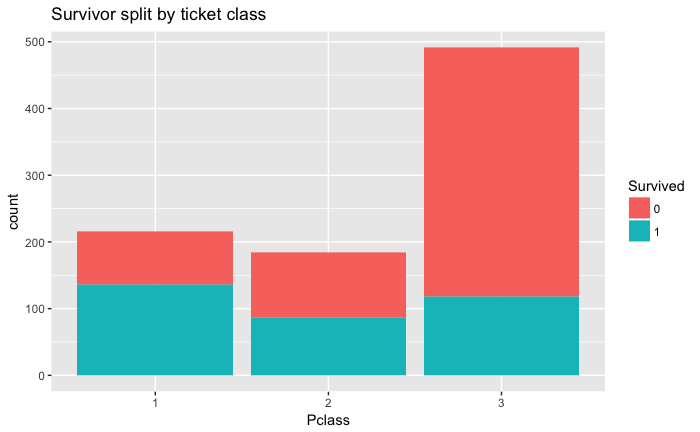

```r
merged$Pclass <- as.factor(merged$Pclass)
merged$Sex <- as.factor(merged$Sex)
g <- ggplot(merged[1:891,], aes(x=Pclass,fill=factor(Survived))) + geom_bar() + labs(fill = "Survived")
g <- g + labs(title="Survivor split by ticket class")
g
```

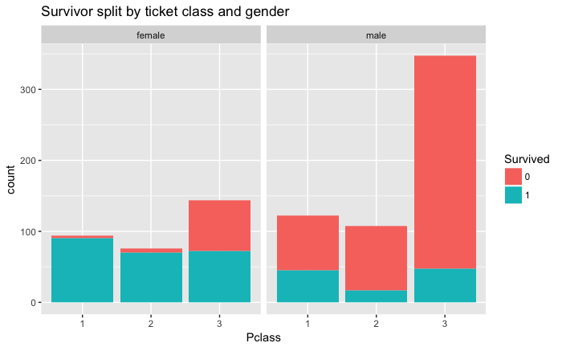

```r
g <- g + facet_wrap(~Sex) + labs(title="Survivor split by ticket class and gender")
g
```

As expected, higher class of ticket and female gender seem to be good positive predictors of survival.

## Age

I would like to segment by age and create a new feature for age bracket as having so many individual ages in the model would probably lead to overfitting.

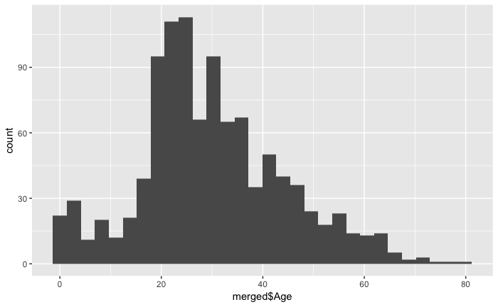

```r
qplot(merged$Age)
```

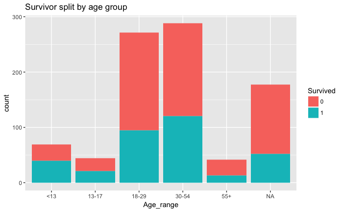

```r
agebrackets <- c(0,13,18,30,55)
merged$Agebracket <- findInterval(merged$Age,agebrackets)
agetable <- data.frame(Agebracket=c(1,2,3,4,5),Age_range=c("<13","13-17","18-29","30-54","55+"))
merged <- join(merged,agetable,by="Agebracket")
merged$Agebracket <- as.factor(merged$Agebracket)
g <- ggplot(merged[1:891,], aes(x=Age_range,fill=factor(Survived))) + geom_bar() + labs(fill = "Survived")
g <- g + labs(title="Survivor split by age group")
g
```

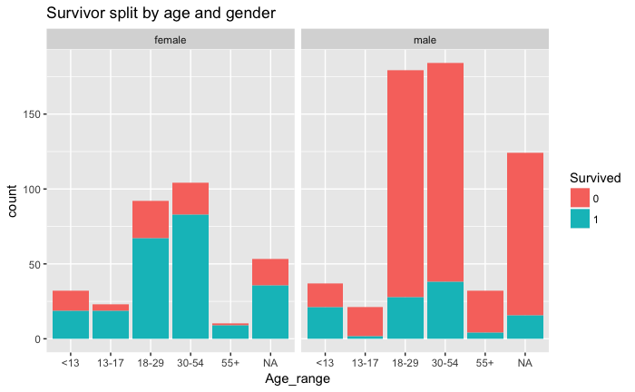

```r
g <- g + facet_wrap(~Sex) + labs(title="Survivor split by age and gender")
g
```

Age bracket seems to give a lot of information, with youger generally having a better chance of survival. Interestingly elderly women has a very good chance of survival whereas elderly men had a very bad chance so it looks like this is a useful division.

# Feature Engineering, Cleaning and Completing the Data

As discussed before I intend to split up the data into those with Age data and those without, this seems pretty central. However I want to see if this improves performance so I will do that once I’ve trained and tested a few models on the comibined set. The other variable with many missing entries is Cabin. I’m guessing this isn’t just missing data, but that a lot of people didn’t have a Cabin. So I’m thinking of turning this into a 2 factor variable, has / does not have cabin.

## Cabin

```r
head(merged$Cabin,30)
```

```
 [1] ""            "C85"         ""            "C123"        ""            ""            "E46"         ""            ""
[10] ""            "G6"          "C103"        ""            ""            ""            ""            ""            ""
[19] ""            ""            ""            "D56"         ""            "A6"          ""            ""            ""
[28] "C23 C25 C27" ""            ""
```

```r
length(unique(merged$Cabin))/length(merged$Cabin) ## only 14% are unique so there are a lot shared.
```

```
[1] 0.1428571
```

```r
merged$Cabin[28] # this looks strange, multiple cabins on one ticket
```

```
[1] "C23 C25 C27"
```

```r
subset(merged,Cabin == "C23 C25 C27") # it was one family, the Fortunes
```

|  | PassengerId | Survived | Pclass | Name | Sex | Age | SibSp | Parch | Ticket | Fare | Cabin | Embarked | Agebracket | Age_range |
| --- | --- | --- | --- | --- | --- | --- | --- | --- | --- | --- | --- | --- | --- | --- |
| 28 | 28 | 0 | 1 | Fortune, Mr. Charles Alexander | male | 19 | 3 | 2 | 19950 | 263 | C23 C25 C27 | S | 3 | 18-29 |
| 89 | 89 | 1 | 1 | Fortune, Miss. Mabel Helen | female | 23 | 3 | 2 | 19950 | 263 | C23 C25 C27 | S | 3 | 18-29 |
| 342 | 342 | 1 | 1 | Fortune, Miss. Alice Elizabeth | female | 24 | 3 | 2 | 19950 | 263 | C23 C25 C27 | S | 3 | 18-29 |
| 439 | 439 | 0 | 1 | Fortune, Mr. Mark | male | 64 | 1 | 4 | 19950 | 263 | C23 C25 C27 | S | 5 | 55+ |
| 945 | 945 | NA | 1 | Fortune, Miss. Ethel Flora | female | 28 | 3 | 2 | 19950 | 263 | C23 C25 C27 | S | 3 | 18-29 |
| 961 | 961 | NA | 1 | Fortune, Mrs. Mark (Mary McDougald) | female | 60 | 1 | 4 | 19950 | 263 | C23 C25 C27 | S | 5 | 55+ |

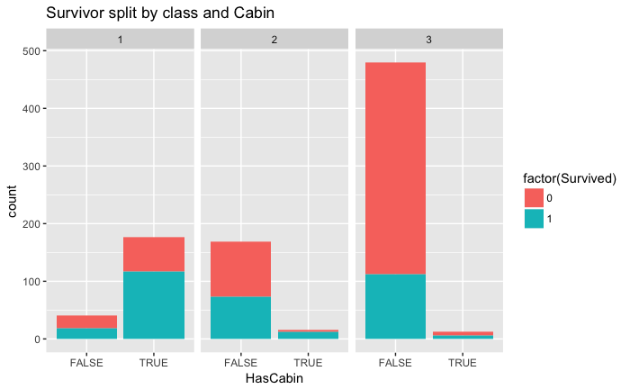

```r
merged$HasCabin <- as.factor(!(merged$Cabin==""))
g <- ggplot(merged[1:891,], aes(x=HasCabin,fill=factor(Survived))) + geom_bar()
g <- g +facet_wrap(~Pclass) + labs(title="Survivor split by class and Cabin")
g
```

As expected few people in Class 2 and 3 had cabins, but actually those who did had a good chance of survival. Helping to capture the smaller number who survived from lower classes should be very additive.

## Fare

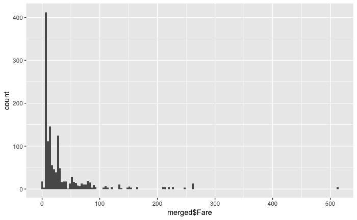

```r
qplot(merged$Fare,bins=150)
```

There doesn’t seem to be natural brackets here unlike age, so I will just split in equal groups. There is one missing entry for Fare, I will impute the average Fare for his Pclass.

```r
subset(merged,is.na(merged$Fare))
```

|  | PassengerId | Survived | Pclass | Name | Sex | Age | SibSp | Parch | Ticket | Fare | Cabin | Embarked | Agebracket | Age_range | HasCabin |
| --- | --- | --- | --- | --- | --- | --- | --- | --- | --- | --- | --- | --- | --- | --- | --- |
| 1044 | 1044 | NA | 3 | Storey, Mr. Thomas | male | 60.5 | 0 | 0 | 3701 | NA |  | S | 5 | 55+ | FALSE |

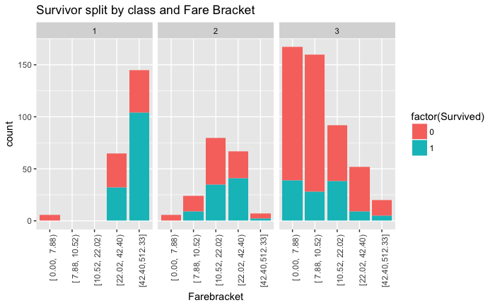

```r
merged[1044,]$Fare <- mean(subset(merged,Pclass==3)$Fare,na.rm=TRUE)
merged$Farebracket <- as.factor(cut2(merged$Fare,g=5))
g <- ggplot(merged[1:891,], aes(x=Farebracket,fill=factor(Survived))) + geom_bar()
g <- g +facet_wrap(~Pclass) + labs(title="Survivor split by class and Fare Bracket")
g <- g + theme(axis.text.x = element_text(angle = 90, hjust = 1))
g
```

```r
head(merged[order(merged$Fare,decreasing = FALSE),]$Fare)
```

```
[1] 0 0 0 0 0 0
```

```r
subset(merged,Fare==0)
```

|  | PassengerId | Survived | Pclass | Name | Sex | Age | SibSp | Parch | Ticket | Fare | Cabin | Embarked | Agebracket | Age_range | HasCabin | Farebracket |
| --- | --- | --- | --- | --- | --- | --- | --- | --- | --- | --- | --- | --- | --- | --- | --- | --- |
| 180 | 180 | 0 | 3 | Leonard, Mr. Lionel | male | 36 | 0 | 0 | LINE | 0 |  | S | 4 | 30-54 | FALSE | [ 0.00, 7.88) |
| 264 | 264 | 0 | 1 | Harrison, Mr. William | male | 40 | 0 | 0 | 112059 | 0 | B94 | S | 4 | 30-54 | TRUE | [ 0.00, 7.88) |
| 272 | 272 | 1 | 3 | Tornquist, Mr. William Henry | male | 25 | 0 | 0 | LINE | 0 |  | S | 3 | 18-29 | FALSE | [ 0.00, 7.88) |
| 278 | 278 | 0 | 2 | Parkes, Mr. Francis "Frank" | male | NA | 0 | 0 | 239853 | 0 |  | S | NA | NA | FALSE | [ 0.00, 7.88) |
| 303 | 303 | 0 | 3 | Johnson, Mr. William Cahoone Jr | male | 19 | 0 | 0 | LINE | 0 |  | S | 3 | 18-29 | FALSE | [ 0.00, 7.88) |
| 414 | 414 | 0 | 2 | Cunningham, Mr. Alfred Fleming | male | NA | 0 | 0 | 239853 | 0 |  | S | NA | NA | FALSE | [ 0.00, 7.88) |
| 467 | 467 | 0 | 2 | Campbell, Mr. William | male | NA | 0 | 0 | 239853 | 0 |  | S | NA | NA | FALSE | [ 0.00, 7.88) |
| 482 | 482 | 0 | 2 | Frost, Mr. Anthony Wood "Archie" | male | NA | 0 | 0 | 239854 | 0 |  | S | NA | NA | FALSE | [ 0.00, 7.88) |
| 598 | 598 | 0 | 3 | Johnson, Mr. Alfred | male | 49 | 0 | 0 | LINE | 0 |  | S | 4 | 30-54 | FALSE | [ 0.00, 7.88) |
| 634 | 634 | 0 | 1 | Parr, Mr. William Henry Marsh | male | NA | 0 | 0 | 112052 | 0 |  | S | NA | NA | FALSE | [ 0.00, 7.88) |

[output cut: 7 more lines]

This is more useful than expected, it does seem to split out the survivors within a class quite nicely. There were 17 people who paid 0 fare including some in first class - I don’t think its worth creating a separate category here though.

One group paid over $500! But is ticket overall cost or each ticket?

```r
head(order(merged$Fare,decreasing = TRUE))
```

```
[1]  259  680  738 1235   28   89
```

```r
merged[259,]
```

|  | PassengerId | Survived | Pclass | Name | Sex | Age | SibSp | Parch | Ticket | Fare | Cabin | Embarked | Agebracket | Age_range | HasCabin | Farebracket |
| --- | --- | --- | --- | --- | --- | --- | --- | --- | --- | --- | --- | --- | --- | --- | --- | --- |
| 259 | 259 | 1 | 1 | Ward, Miss. Anna | female | 35 | 0 | 0 | PC 17755 | 512.3292 |  | C | 4 | 30-54 | FALSE | [42.40,512.33] |

```r
subset(merged,Fare==merged$Fare[259])
```

|  | PassengerId | Survived | Pclass | Name | Sex | Age | SibSp | Parch | Ticket | Fare | Cabin | Embarked | Agebracket | Age_range | HasCabin | Farebracket |
| --- | --- | --- | --- | --- | --- | --- | --- | --- | --- | --- | --- | --- | --- | --- | --- | --- |
| 259 | 259 | 1 | 1 | Ward, Miss. Anna | female | 35 | 0 | 0 | PC 17755 | 512.3292 |  | C | 4 | 30-54 | FALSE | [42.40,512.33] |
| 680 | 680 | 1 | 1 | Cardeza, Mr. Thomas Drake Martinez | male | 36 | 0 | 1 | PC 17755 | 512.3292 | B51 B53 B55 | C | 4 | 30-54 | TRUE | [42.40,512.33] |
| 738 | 738 | 1 | 1 | Lesurer, Mr. Gustave J | male | 35 | 0 | 0 | PC 17755 | 512.3292 | B101 | C | 4 | 30-54 | TRUE | [42.40,512.33] |
| 1235 | 1235 | NA | 1 | Cardeza, Mrs. James Warburton Martinez (Charlotte Wardle Drake) | female | 58 | 0 | 1 | PC 17755 | 512.3292 | B51 B53 B55 | C | 5 | 55+ | TRUE | [42.40,512.33] |

Just for fun: from https://en.wikipedia.org/wiki/Titanic_(1997_film) Jack Dawson is actually Joseph Dawson, who is not in our sample, and neither is Rose. I didn’t need a model to classify them anyway.

```r
grep("Dawson",merged$Name)
```

```
integer(0)
```

```r
grep("Rose",merged$Name)
```

```
[1]  856 1100 1219
```

## Title

```r
merged$Title <- gsub('(.*, )|(\\..*)', '', merged$Name)
count(merged,Title)
```

| Title | n |
| --- | --- |
| Capt | 1 |
| Col | 4 |
| Don | 1 |
| Dona | 1 |
| Dr | 8 |
| Jonkheer | 1 |
| Lady | 1 |
| Major | 2 |
| Master | 61 |
| Miss | 260 |

[output cut: 8 more lines]

```r
VIP <- c("Capt","Col","Don","Dona","Dr","Jonkheer","Lady","Major",
         "Mlle", "Mme","Rev","Sir","the Countess")
merged$Title[merged$Title %in% VIP] <- "VIP"
merged$Title <- as.factor(merged$Title)
count(merged,Title)
```

| Title | n |
| --- | --- |
| Master | 61 |
| Miss | 260 |
| Mr | 757 |
| Mrs | 197 |
| Ms | 2 |
| VIP | 32 |

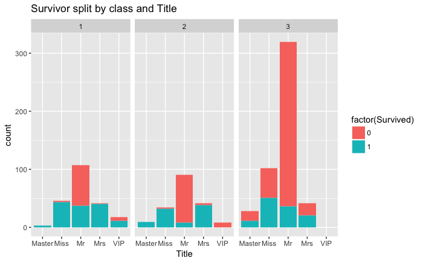

```r
## I'm not that keen on only having 2 in the "Ms" camp
merged[merged$Title=="Ms",]$Title <- "Mrs"
g <- ggplot(merged[1:891,], aes(x=Title,fill=factor(Survived))) + geom_bar()
g <- g +facet_wrap(~Pclass) + labs(title="Survivor split by class and Title")
g
```

I’m not sure how useful this is going to be based on the charts.

## Name

Onto surname, I’m interested to see if there was some racial bias here.

```r
library(wru) # who r u - library to guess race from surname
merged$surname<- gsub("([A-Za-z]+).*", "\\1", merged$Name)
predict_race(merged,surname.only = TRUE)
```

```
[1] "Proceeding with surname-only predictions..."
```

```
Probabilities were imputed for 271 surnames that could not be matched to Census list.
```

|  | PassengerId | Survived | Pclass | Name | Sex | Age | SibSp | Parch | Ticket | Fare | Cabin | Embarked | Agebracket | Age_range | HasCabin | Farebracket | Title | surname | pred.whi | pred.bla | pred.his | pred.asi | pred.oth |
| --- | --- | --- | --- | --- | --- | --- | --- | --- | --- | --- | --- | --- | --- | --- | --- | --- | --- | --- | --- | --- | --- | --- | --- |
| 156 | 1 | 0 | 3 | Braund, Mr. Owen Harris | male | 22.00 | 1 | 0 | A/5 21171 | 7.2500 |  | S | 3 | 18-29 | FALSE | [ 0.00, 7.88) | Mr | Braund | 0.95720000 | 0.013700000 | 0.010300000 | 0.005100000 | 0.013700000 |
| 287 | 2 | 1 | 1 | Cumings, Mrs. John Bradley (Florence Briggs Thayer) | female | 38.00 | 1 | 0 | PC 17599 | 71.2833 | C85 | C | 4 | 30-54 | TRUE | [42.40,512.33] | Mrs | Cumings | 0.89970000 | 0.046300000 | 0.027800000 | 0.010800000 | 0.015400000 |
| 532 | 3 | 1 | 3 | Heikkinen, Miss. Laina | female | 26.00 | 0 | 0 | STON/O2. 3101282 | 7.9250 |  | S | 3 | 18-29 | FALSE | [ 7.88, 10.52) | Miss | Heikkinen | 0.95680000 | 0.001350000 | 0.013500000 | 0.008100000 | 0.020250000 |
| 431 | 4 | 1 | 1 | Futrelle, Mrs. Jacques Heath (Lily May Peel) | female | 35.00 | 1 | 0 | 113803 | 53.1000 | C123 | S | 4 | 30-54 | TRUE | [42.40,512.33] | Mrs | Futrelle | 0.91430000 | 0.057100000 | 0.009533333 | 0.000000000 | 0.019066667 |
| 22 | 5 | 0 | 3 | Allen, Mr. William Henry | male | 35.00 | 0 | 0 | 373450 | 8.0500 |  | S | 4 | 30-54 | FALSE | [ 7.88, 10.52) | Mr | Allen | 0.67583242 | 0.261673833 | 0.024697530 | 0.005399460 | 0.032396760 |
| 828 | 6 | 0 | 3 | Moran, Mr. James | male | NA | 0 | 0 | 330877 | 8.4583 |  | Q | NA | NA | FALSE | [ 7.88, 10.52) | Mr | Moran | 0.64140000 | 0.024300000 | 0.308100000 | 0.007000000 | 0.019200000 |
| 777 | 7 | 0 | 1 | McCarthy, Mr. Timothy J | male | 54.00 | 0 | 0 | 17463 | 51.8625 | E46 | S | 4 | 30-54 | TRUE | [42.40,512.33] | Mr | McCarthy | 0.92290000 | 0.032500000 | 0.022400000 | 0.006800000 | 0.015400000 |
| 1811 | 8 | 0 | 3 | Palsson, Master. Gosta Leonard | male | 2.00 | 3 | 1 | 349909 | 21.0750 |  | S | 1 | <13 | FALSE | [10.52, 22.02) | Master | Palsson | 0.66650000 | 0.085300000 | 0.136700000 | 0.079700000 | 0.031800000 |
| 613 | 9 | 1 | 3 | Johnson, Mrs. Oscar W (Elisabeth Vilhelmina Berg) | female | 27.00 | 0 | 2 | 347742 | 11.1333 |  | S | 3 | 18-29 | FALSE | [10.52, 22.02) | Mrs | Johnson | 0.58970000 | 0.346300000 | 0.023600000 | 0.005400000 | 0.035000000 |
| 856 | 10 | 1 | 2 | Nasser, Mrs. Nicholas (Adele Achem) | female | 14.00 | 1 | 0 | 237736 | 30.0708 |  | C | 2 | 13-17 | FALSE | [22.02, 42.40) | Mrs | Nasser | 0.79260000 | 0.030000000 | 0.054600000 | 0.047100000 | 0.075700000 |

[output cut: 990 more lines]

```r
raceprobs <- predict_race(merged,surname.only = TRUE)[18:22]
```

```
[1] "Proceeding with surname-only predictions..."
```

```
Probabilities were imputed for 271 surnames that could not be matched to Census list.
```

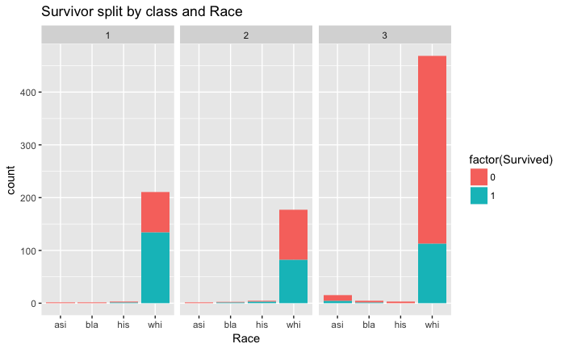

```r
racepreds <- suppressWarnings(colnames(raceprobs)[apply(raceprobs,1,which.max)])
merged$Race <- as.factor(sub('.*\\.', '',racepreds))
g <- ggplot(merged[1:891,], aes(x=Race,fill=factor(Survived))) + geom_bar()
g <- g +facet_wrap(~Pclass) + labs(title="Survivor split by class and Race")
g
```

It looks like such a high proportion is white that this will be of little use.

## Ticketsize variable

Create a variable for number of people on a single tickt to give a count for group size.

```r
merged <- ddply(merged,.(Ticket),transform,Ticketsize=length(Ticket))
merged$Ticketsize <- as.factor(merged$Ticketsize)
merged <- merged[order(merged$PassengerId),] # ddply mixes up order
```

## Embarked

Move the two cases where this is unmarked to the modal case, “S”

```r
count(merged,Embarked) #I'm just going to use the most frequent here ie S
```

| Embarked | n |
| --- | --- |
|  | 2 |
| C | 270 |
| Q | 123 |
| S | 914 |

```r
subset(merged,Embarked == "")
```

|  | PassengerId | Survived | Pclass | Name | Sex | Age | SibSp | Parch | Ticket | Fare | Cabin | Embarked | Agebracket | Age_range | HasCabin | Farebracket | Title | surname | Race | Ticketsize |
| --- | --- | --- | --- | --- | --- | --- | --- | --- | --- | --- | --- | --- | --- | --- | --- | --- | --- | --- | --- | --- |
| 59 | 62 | 1 | 1 | Icard, Miss. Amelie | female | 38 | 0 | 0 | 113572 | 80 | B28 |  | 4 | 30-54 | TRUE | [42.40,512.33] | Miss | Icard | whi | 2 |
| 60 | 830 | 1 | 1 | Stone, Mrs. George Nelson (Martha Evelyn) | female | 62 | 0 | 0 | 113572 | 80 | B28 |  | 5 | 55+ | TRUE | [42.40,512.33] | Mrs | Stone | whi | 2 |

```r
merged[c(62,830),"Embarked"] <- "S"
merged$Embarked <- as.factor(merged$Embarked)
```

## Age

To begin with, I want to use the mice library to impute the missing ages. Then I want to check if we get improvement by splitting data as explained above; this seems pivtotal to the analysis.

```r
factors <- c("Pclass","Sex","Agebracket","Title")
set.seed(1234)
mice_ages <- mice(m1[, !names(m1) %in% factors], method='rf')
mice_out <- complete(mice_ages)
# I am creating a new variable for the imputed ages because I want to later compare to
# training a model both for entries with and without ages.
```

```r
mergedages <- merged[,!names(merged) == "Age_range"]
mergedages$Age <- mice_out$Age
mergedages$Agebracket <- findInterval(mergedages$Age,agebrackets)
mergedages <- join(mergedages,agetable,by="Agebracket")
mergedages$Agebracket <- as.factor(mergedages$Agebracket)
colSums(is.na(mergedages))
```

```
PassengerId    Survived      Pclass        Name         Sex         Age       SibSp       Parch      Ticket        Fare
          0           0           0           0           0           0           0           0           0           0
      Cabin    Embarked  Agebracket    HasCabin Farebracket       Title     surname        Race  Ticketsize   Age_range
          0           0           0           0           0           0           0           0           0           0
```

```r
colSums(mergedages=="")
```

```
PassengerId    Survived      Pclass        Name         Sex         Age       SibSp       Parch      Ticket        Fare
          0           0           0           0           0           0           0           0           0           0
      Cabin    Embarked  Agebracket    HasCabin Farebracket       Title     surname        Race  Ticketsize   Age_range
       1014           0           0           0           0           0           0           0           0           0
```

We are ready to start fitting some models!

# Model Fitting

First split the data back into training/ CV and set we use for submission,

```r
mergedagestrain <- mergedages[1:891,]
mergedagestest <- mergedages[892:1309,]
mergedagestrain$Survived <- as.factor(traindata$Survived)
set.seed(414)
inTrain<- createDataPartition(y=mergedagestrain$Survived,p=0.75, list=FALSE)
train <- mergedagestrain[inTrain,]
test <- mergedagestrain[-inTrain,]
```

## Logistic Regression

```r
set.seed(414)
logreg <- glm(Survived ~ Pclass + Sex + Agebracket +
                      Farebracket + HasCabin + Ticketsize
               + Title + Embarked, family = binomial(link=logit),
              data = train)
summary(logreg)
```

```
Call:
glm(formula = Survived ~ Pclass + Sex + Agebracket + Farebracket +
    HasCabin + Ticketsize + Title + Embarked, family = binomial(link = logit),
    data = train)

Deviance Residuals:
    Min       1Q   Median       3Q      Max
-2.0284  -0.5244  -0.3535   0.5250   2.4946

Coefficients:
                            Estimate Std. Error z value Pr(>|z|)
(Intercept)                1.932e+01  1.689e+03   0.011 0.990872
Pclass2                   -6.845e-02  6.333e-01  -0.108 0.913929
Pclass3                   -1.229e+00  7.174e-01  -1.713 0.086721 .
Sexmale                   -1.727e+01  1.689e+03  -0.010 0.991842
Agebracket2                4.314e-01  6.433e-01   0.671 0.502472
Agebracket3                5.612e-01  4.648e-01   1.207 0.227284
Agebracket4                5.311e-01  4.727e-01   1.124 0.261167
Agebracket5                5.110e-01  6.097e-01   0.838 0.402041
Farebracket[ 7.88, 10.52)  6.453e-02  4.021e-01   0.161 0.872476
Farebracket[10.52, 22.02) -1.561e-01  4.691e-01  -0.333 0.739333
Farebracket[22.02, 42.40) -1.221e-01  5.811e-01  -0.210 0.833610
Farebracket[42.40,512.33]  2.348e-01  9.070e-01   0.259 0.795700
HasCabinTRUE               1.193e+00  4.526e-01   2.635 0.008420 **
Ticketsize2               -2.742e-01  4.315e-01  -0.635 0.525118
Ticketsize3                2.929e-01  5.270e-01   0.556 0.578390
Ticketsize4                6.479e-01  6.449e-01   1.005 0.315029
Ticketsize5               -2.171e+00  8.602e-01  -2.524 0.011598 *
Ticketsize6               -2.937e+00  8.775e-01  -3.348 0.000815 ***
Ticketsize7               -1.794e+00  9.425e-01  -1.904 0.056953 .
Ticketsize8               -5.293e-01  1.552e+00  -0.341 0.733153
Ticketsize11              -1.567e+01  8.825e+02  -0.018 0.985832
TitleMiss                 -1.765e+01  1.689e+03  -0.010 0.991659
TitleMr                   -3.557e+00  6.456e-01  -5.510 3.60e-08 ***
TitleMrs                  -1.714e+01  1.689e+03  -0.010 0.991900
TitleVIP                  -4.126e+00  1.056e+00  -3.906 9.38e-05 ***
EmbarkedQ                 -7.082e-03  4.958e-01  -0.014 0.988603
EmbarkedS                 -5.686e-01  3.085e-01  -1.843 0.065319 .
---
Signif. codes:  0 ‘***’ 0.001 ‘**’ 0.01 ‘*’ 0.05 ‘.’ 0.1 ‘ ’ 1

(Dispersion parameter for binomial family taken to be 1)

    Null deviance: 891.19  on 668  degrees of freedom
Residual deviance: 516.28  on 642  degrees of freedom
AIC: 570.28

Number of Fisher Scoring iterations: 15
```

```r
prediction <- predict(logreg,newdata=test,type="response")
prediction <- ifelse(prediction > 0.5,1,0)
misClasificError <- mean(prediction != test$Survived)
print(paste('Accuracy',1-misClasificError)) ## Accuracy 81%
```

```
[1] "Accuracy 0.806306306306306"
```

## Regularised Logistic Regression using lasso

Let’s see if we can improve the model using lasso regularisation

```r
set.seed(414)
library(glmnet)
x <- model.matrix(Survived ~ Pclass + Sex + Farebracket + HasCabin + Ticketsize + Embarked + Title,train)
cv.out <- cv.glmnet(x,y=train$Survived,alpha=1,family="binomial",type.measure = "mse") #select lambda -4
#best value of lambda
lambda_1se <- cv.out$lambda.1se
xtest <- model.matrix(Survived ~ Pclass + Sex + Farebracket + HasCabin + Ticketsize + Embarked + Title,test)
lasso_prob <- predict(cv.out,newx = xtest,s=lambda_1se,type="response")
#translate probabilities to predictions
lasso_predict <- rep("0",nrow(test))
lasso_predict[lasso_prob>.5] <-"1"
#confusion matrix
table(pred=lasso_predict,true=test$Survived)
```

```
    true
pred   0   1
   0 117  20
   1  20  65
```

```r
mean(lasso_predict==test$Survived) #82% accuracy
```

```
[1] 0.8198198
```

## Random Forest

```r
set.seed(414)
rf_model <- randomForest(factor(Survived) ~ Pclass + Sex + Agebracket +
                                 Farebracket + Race + HasCabin + Ticketsize +
                                 Embarked + Title,
                         data = mergedagestrain,na.action = na.pass)
rf_model
```

```
Call:
 randomForest(formula = factor(Survived) ~ Pclass + Sex + Agebracket +      Farebracket + Race + HasCabin + Ticketsize + Embarked + Title,      data = mergedagestrain, na.action = na.pass)
               Type of random forest: classification
                     Number of trees: 500
No. of variables tried at each split: 3

        OOB estimate of  error rate: 18.07%
Confusion matrix:
    0   1 class.error
0 489  60   0.1092896
1 101 241   0.2953216
```

```r
rf_model$confusion
```

```
    0   1 class.error
0 489  60   0.1092896
1 101 241   0.2953216
```

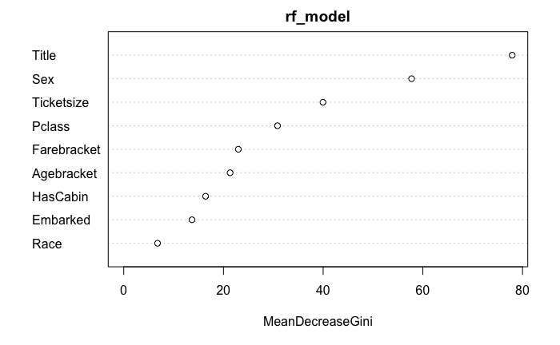

```r
varImpPlot(rf_model)
```

```r
importance(rf_model)
```

```
            MeanDecreaseGini
Pclass              30.83820
Sex                 57.74363
Agebracket          21.33787
Farebracket         22.98314
Race                 6.77651
HasCabin            16.41611
Ticketsize          39.96358
Embarked            13.68822
Title               77.92766
```

```r
set.seed(414)
rf_model2 <- randomForest(factor(Survived) ~ Pclass + Sex + Farebracket + HasCabin + Ticketsize + Embarked + Title,
                         data = mergedagestrain,na.action = na.pass,nodesize=20)
rf_model2 #looks the best
```

```
Call:
 randomForest(formula = factor(Survived) ~ Pclass + Sex + Farebracket +      HasCabin + Ticketsize + Embarked + Title, data = mergedagestrain,      nodesize = 20, na.action = na.pass)
               Type of random forest: classification
                     Number of trees: 500
No. of variables tried at each split: 2

        OOB estimate of  error rate: 16.27%
Confusion matrix:
    0   1 class.error
0 501  48  0.08743169
1  97 245  0.28362573
```

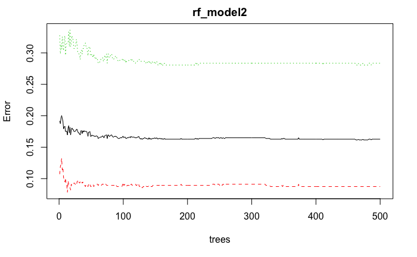

```r
plot(rf_model2)
```

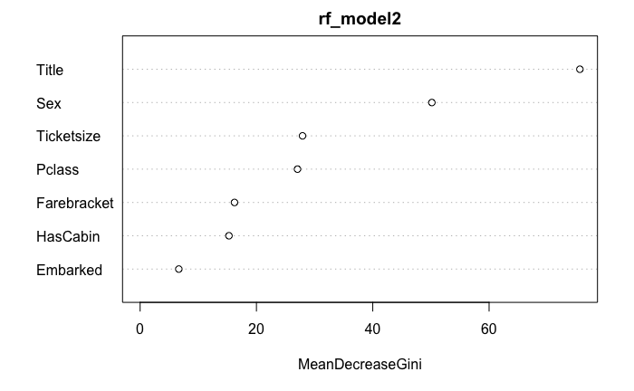

```r
varImpPlot(rf_model2)
```

```r
importance(rf_model2)
```

```
            MeanDecreaseGini
Pclass             27.060232
Sex                50.163080
Farebracket        16.228239
HasCabin           15.272008
Ticketsize         27.926492
Embarked            6.651349
Title              75.613812
```

## GBM

```r
features <- c("Survived","Pclass","Sex","SibSp","Parch","HasCabin","Farebracket","Title","Ticketsize","Age_range")
fitControl <- trainControl(method = "repeatedcv", number = 4, repeats = 4)
set.seed(414)
gbm1 <- suppressWarnings(train(as.factor(Survived) ~ ., data = train[features],
              method = "gbm", trControl = fitControl,verbose = FALSE))
prediction <- predict(gbm1, test[features],type= "prob")
prediction <- data.frame(ifelse(prediction[,2] > 0.5,1,0))
mean(prediction[,1] == test$Survived) #82% accuracy
```

```
[1] 0.8288288
```

```r
set.seed(414)
fitControl2 <- trainControl(method = "repeatedcv", number = 6, repeats = 4)
gbm2 <- suppressWarnings(train(as.factor(Survived) ~ ., data = train[features],
              method = "gbm", trControl = fitControl,verbose = FALSE))
prediction <- predict(gbm2, test[features],type= "prob")
prediction <- data.frame(ifelse(prediction[,2] > 0.5,1,0))
mean(prediction[,1] == test$Survived) #82.5% accuracy
```

```
[1] 0.8288288
```

## Splitting models depending on whether age is available or not

```r
row.names(merged) <- merged$PassengerId
mergedtrain <- merged[1:891,]
mergedtest <- merged[892:1309,]
mergedtrain$Survived <- as.factor(mergedtrain$Survived)
sum(is.na(mergedtrain$Age))
```

```
[1] 177
```

```r
sum(is.na(mergedtest$Age))
```

```
[1] 86
```

```r
mergedtrain[is.na(mergedtrain$Age),]
```

|  | PassengerId | Survived | Pclass | Name | Sex | Age | SibSp | Parch | Ticket | Fare | Cabin | Embarked | Agebracket | Age_range | HasCabin | Farebracket | Title | surname | Race | Ticketsize |
| --- | --- | --- | --- | --- | --- | --- | --- | --- | --- | --- | --- | --- | --- | --- | --- | --- | --- | --- | --- | --- |
| 6 | 6 | 0 | 3 | Moran, Mr. James | male | NA | 0 | 0 | 330877 | 8.4583 |  | Q | NA | NA | FALSE | [ 7.88, 10.52) | Mr | Moran | whi | 1 |
| 18 | 18 | 1 | 2 | Williams, Mr. Charles Eugene | male | NA | 0 | 0 | 244373 | 13.0000 |  | S | NA | NA | FALSE | [10.52, 22.02) | Mr | Williams | bla | 1 |
| 20 | 20 | 1 | 3 | Masselmani, Mrs. Fatima | female | NA | 0 | 0 | 2649 | 7.2250 |  | C | NA | NA | FALSE | [ 0.00, 7.88) | Mrs | Masselmani | whi | 1 |
| 27 | 27 | 0 | 3 | Emir, Mr. Farred Chehab | male | NA | 0 | 0 | 2631 | 7.2250 |  | C | NA | NA | FALSE | [ 0.00, 7.88) | Mr | Emir | whi | 1 |
| 29 | 29 | 1 | 3 | O'Dwyer, Miss. Ellen "Nellie" | female | NA | 0 | 0 | 330959 | 7.8792 |  | Q | NA | NA | FALSE | [ 7.88, 10.52) | Miss | O | whi | 1 |
| 30 | 30 | 0 | 3 | Todoroff, Mr. Lalio | male | NA | 0 | 0 | 349216 | 7.8958 |  | S | NA | NA | FALSE | [ 7.88, 10.52) | Mr | Todoroff | whi | 1 |
| 32 | 32 | 1 | 1 | Spencer, Mrs. William Augustus (Marie Eugenie) | female | NA | 1 | 0 | PC 17569 | 146.5208 | B78 | C | NA | NA | TRUE | [42.40,512.33] | Mrs | Spencer | whi | 3 |
| 33 | 33 | 1 | 3 | Glynn, Miss. Mary Agatha | female | NA | 0 | 0 | 335677 | 7.7500 |  | Q | NA | NA | FALSE | [ 0.00, 7.88) | Miss | Glynn | whi | 1 |
| 37 | 37 | 1 | 3 | Mamee, Mr. Hanna | male | NA | 0 | 0 | 2677 | 7.2292 |  | C | NA | NA | FALSE | [ 0.00, 7.88) | Mr | Mamee | whi | 1 |
| 43 | 43 | 0 | 3 | Kraeff, Mr. Theodor | male | NA | 0 | 0 | 349253 | 7.8958 |  | C | NA | NA | FALSE | [ 7.88, 10.52) | Mr | Kraeff | whi | 1 |

[output cut: 167 more lines]

```r
mergedtrain[!is.na(mergedtrain$Age),]
```

|  | PassengerId | Survived | Pclass | Name | Sex | Age | SibSp | Parch | Ticket | Fare | Cabin | Embarked | Agebracket | Age_range | HasCabin | Farebracket | Title | surname | Race | Ticketsize |
| --- | --- | --- | --- | --- | --- | --- | --- | --- | --- | --- | --- | --- | --- | --- | --- | --- | --- | --- | --- | --- |
| 1 | 1 | 0 | 3 | Braund, Mr. Owen Harris | male | 22.00 | 1 | 0 | A/5 21171 | 7.2500 |  | S | 3 | 18-29 | FALSE | [ 0.00, 7.88) | Mr | Braund | whi | 1 |
| 2 | 2 | 1 | 1 | Cumings, Mrs. John Bradley (Florence Briggs Thayer) | female | 38.00 | 1 | 0 | PC 17599 | 71.2833 | C85 | C | 4 | 30-54 | TRUE | [42.40,512.33] | Mrs | Cumings | whi | 2 |
| 3 | 3 | 1 | 3 | Heikkinen, Miss. Laina | female | 26.00 | 0 | 0 | STON/O2. 3101282 | 7.9250 |  | S | 3 | 18-29 | FALSE | [ 7.88, 10.52) | Miss | Heikkinen | whi | 1 |
| 4 | 4 | 1 | 1 | Futrelle, Mrs. Jacques Heath (Lily May Peel) | female | 35.00 | 1 | 0 | 113803 | 53.1000 | C123 | S | 4 | 30-54 | TRUE | [42.40,512.33] | Mrs | Futrelle | whi | 2 |
| 5 | 5 | 0 | 3 | Allen, Mr. William Henry | male | 35.00 | 0 | 0 | 373450 | 8.0500 |  | S | 4 | 30-54 | FALSE | [ 7.88, 10.52) | Mr | Allen | whi | 1 |
| 7 | 7 | 0 | 1 | McCarthy, Mr. Timothy J | male | 54.00 | 0 | 0 | 17463 | 51.8625 | E46 | S | 4 | 30-54 | TRUE | [42.40,512.33] | Mr | McCarthy | whi | 2 |
| 8 | 8 | 0 | 3 | Palsson, Master. Gosta Leonard | male | 2.00 | 3 | 1 | 349909 | 21.0750 |  | S | 1 | <13 | FALSE | [10.52, 22.02) | Master | Palsson | whi | 5 |
| 9 | 9 | 1 | 3 | Johnson, Mrs. Oscar W (Elisabeth Vilhelmina Berg) | female | 27.00 | 0 | 2 | 347742 | 11.1333 |  | S | 3 | 18-29 | FALSE | [10.52, 22.02) | Mrs | Johnson | whi | 3 |
| 10 | 10 | 1 | 2 | Nasser, Mrs. Nicholas (Adele Achem) | female | 14.00 | 1 | 0 | 237736 | 30.0708 |  | C | 2 | 13-17 | FALSE | [22.02, 42.40) | Mrs | Nasser | whi | 2 |
| 11 | 11 | 1 | 3 | Sandstrom, Miss. Marguerite Rut | female | 4.00 | 1 | 1 | PP 9549 | 16.7000 | G6 | S | 1 | <13 | TRUE | [10.52, 22.02) | Miss | Sandstrom | whi | 3 |

[output cut: 704 more lines]

```r
rf_model_ages <- randomForest(factor(Survived) ~ Pclass + Sex + Farebracket + HasCabin + Agebracket + Ticketsize + Embarked + Title,
                              data = mergedtrain[!is.na(mergedtrain$Age),],nodesize=20)
rf_model_ages
```

```
Call:
 randomForest(formula = factor(Survived) ~ Pclass + Sex + Farebracket +      HasCabin + Agebracket + Ticketsize + Embarked + Title, data = mergedtrain[!is.na(mergedtrain$Age),      ], nodesize = 20)
               Type of random forest: classification
                     Number of trees: 500
No. of variables tried at each split: 2

        OOB estimate of  error rate: 17.37%
Confusion matrix:
    0   1 class.error
0 386  38  0.08962264
1  86 204  0.29655172
```

```r
rf_model_ages$confusion
```

```
    0   1 class.error
0 386  38  0.08962264
1  86 204  0.29655172
```

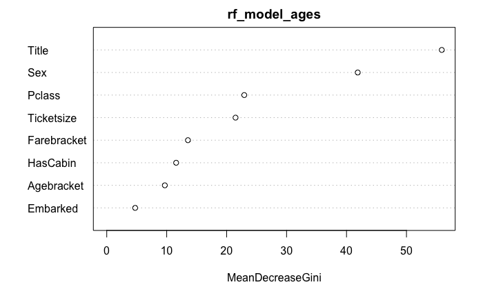

```r
varImpPlot(rf_model_ages)
```

```r
importance(rf_model_ages)
```

```
            MeanDecreaseGini
Pclass             22.937832
Sex                41.870459
Farebracket        13.543902
HasCabin           11.574452
Agebracket          9.687917
Ticketsize         21.484251
Embarked            4.743146
Title              55.889685
```

```r
rf_model_noages <- randomForest(factor(Survived) ~ Pclass + Sex +
                                      Farebracket + Race + HasCabin + Ticketsize +
                                      Embarked + Title,
                              data = mergedtrain[is.na(mergedtrain$Age),],nodesize=20)
rf_model_noages
```

```
Call:
 randomForest(formula = factor(Survived) ~ Pclass + Sex + Farebracket +      Race + HasCabin + Ticketsize + Embarked + Title, data = mergedtrain[is.na(mergedtrain$Age),      ], nodesize = 20)
               Type of random forest: classification
                     Number of trees: 500
No. of variables tried at each split: 2

        OOB estimate of  error rate: 14.69%
Confusion matrix:
    0  1 class.error
0 116  9   0.0720000
1  17 35   0.3269231
```

```r
rf_model_noages$confusion
```

```
    0  1 class.error
0 116  9   0.0720000
1  17 35   0.3269231
```

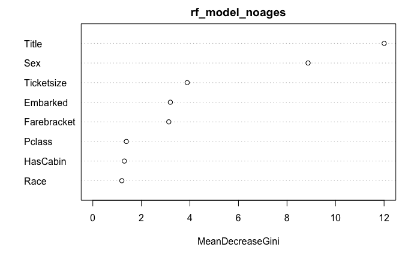

```r
varImpPlot(rf_model_noages)
```

```r
importance(rf_model_noages)
```

```
            MeanDecreaseGini
Pclass              1.379995
Sex                 8.868790
Farebracket         3.129364
Race                1.195556
HasCabin            1.299080
Ticketsize          3.888380
Embarked            3.194861
Title              12.002774
```

```r
p1 <- predict(rf_model_ages, mergedtest[!is.na(mergedtest$Age),])
p2 <- predict(rf_model_noages, mergedtest[is.na(mergedtest$Age),])
prediction <- join(data.frame(PassengerId=names(p1),Survived=p1),data.frame(PassengerId=names(p2),Survived=p2))
# This actually didn't help my position on the leaderboard, pretty surprised by this
```

# Evaluation and submission

The model rf2 looks the best so I will submit that.

```r
prediction <- predict(rf_model2, mergedagestest)
submission <- data.frame(PassengerId=names(prediction),Survived=prediction)
if(!file.exists("./predictions.csv")) {
        write.csv(submission, file = "./predictions.csv",row.names = F)}
```

This submission got me into the top 6% which I was very pleased with for my first attempt.

I am a little puzzled how many of my intuitions were wrong, that splitting age into two models would make a big difference, and the clearly crucial feature “Title” would not have much impact.

For my next project I want to take a more purposeful approach to model selection, with a more extensive evaluation and diagnostics for parameter tuning. I also want to work on seeing how feature engineering and model selection work in concert with each other.

Thanks for reading, if you’ve got this far surely its worth an upvote :)